# The Doughnut

Macroeconomic Boundaries and a conceptual framework that combines environmental and economic indicators

# Resources

[video not shown]

[02 Slides - The Doughnut - Macroeconomic Boundaries and a conceptual framework that combine environmental and economic indicators](https://drive.google.com/file/d/1IaoU9d3qoaAUvarg8NiiVU79-VK7vWtF/view?usp=sharing)

[Doughnut Indicators](https://docs.google.com/spreadsheets/d/1VFG8PCKcFp3nLp2EuhjdK50w9YvGsG1D?rtpof=true&usp=drive_fs)

## Readings

[Doughnut Economics Site](https://doughnuteconomics.org/doughnut)

[Chapter 1 of Doughnut Economics Book](https://doughnuteconomics.org/tools/chapter-one-of-doughnut-economics)

[Fanning and Raworth 2025 in Nature](https://doi.org/10.1038/s41586-025-09385-1)

# Content

## Course Framing: Earth and Economy as Interlinked Systems

### The Global Perspective

The first day of class established the general context for why environment and natural resource economics matters, specifically examining how the Earth and the economy should be understood as interlinked systems. This framing preceded the schedule discussion because talking through schedule details without context is always tedious.

One of the value-added elements of this course compared to a traditional environment and natural resources course is its global framing. Traditional courses often feel like disconnected slices: How do you optimally manage fisheries? How do you prevent pollution when it is a non-point-source problem? These are important questions that will be addressed, but the broader framing ties everything together.

### Course Structure Overview

The course is organized into several major sections that correspond to different parts of the website and eventual book.

#### Part One: Introduction

The introduction establishes the global context, arguing that environment and natural resources must be seen in a global setting. This was covered in the first lecture.

#### Part Two: The Donut and Economic Tools

The second lecture focuses on the donut, or macroeconomic boundaries. This conceptual framework combines environmental and economic indicators in a useful way. After establishing the broad context, the course reviews specific economic tools in what is called the “micro-filling,” a pun on filled donuts.

Economics has a comprehensive and theoretically sound basis for why people do what they do. This foundation is valuable even though it can be abused in certain cases. The course goes further than introductory economics but not as far as intermediate microeconomics, examining consumer preferences, utility curves, and indifference curves to build up the fundamental tools underlying environment and natural resource economics.

Supply and demand will be reintroduced quickly, as these concepts are central to understanding externalities. Together, these tools are sufficient to define cost-benefit analysis, which many people consider the point of environment and natural resources in policy spaces. Cost-benefit analysis has been critical to the environmental protection journey various countries have undergone. Plants or potentially polluting activities are not undertaken without considering all costs and benefits, which is particularly important in environmental domains because environmental costs are often ignored by those who want to build factories.

The course will apply these concepts to optimal pollution. For economics-minded students, this concept does not require much selling. However, ecologists often strongly dislike the idea of optimal pollution, arguing there should be none of it. The course argues this view is incorrect. There are marginal benefits to eliminating pollution, clearly, but there are also marginal costs of abatement. The framework demonstrates that some level of pollution is optimal, though it is almost always far less than current levels.

#### Part Three: Market Failures

Once the economic tools are established, the course addresses the first of two bread-and-butter parts of a typical environment economics course: using tools to understand market failures. Introductory courses typically cover market failures including externalities, public goods, and commons dilemmas. These are three cases where perfect competition falls apart and is not optimal, requiring either acceptance of suboptimal outcomes or solutions to the market failures.

A typical course would spend most of its time discussing, using climate change as an example, how emissions generate externalities. The coal-fired power plant owner cares about profitability from electricity but perhaps not the impact on the rest of the world through climate damages.

Climate change involves externalities, but it is also a public good problem. Protecting the climate and reducing emissions provides benefits, but everyone else also receives those benefits. As one of eight billion people, personal benefits from reducing individual emissions are quite small, making this a hardcore public goods problem.

Climate is also a commons. The atmosphere’s capacity to absorb carbon is a finite commons good, but there is no way to prevent people from using it. Climate change will be used throughout as an example of the ultimate market failure because it fails on all three dimensions. Other market failures exist, like stinky hog manure with spillover effects, but climate change receives emphasis.

#### Part Four: Macroeconomic Sustainability Indicators

With the environmental framing in place, the course adds newer material by zooming back out to think about more detailed indicators of macroeconomic sustainability. This new framing considers how all parts of the economy are impacted and how they fit together in complex equilibrium. General equilibrium will be discussed, but a more general version that considers the Earth.

GDP will be examined as a flawed indicator, along with potential replacements, though the argument is made that GDP is actually a good indicator for what it is designed to measure.

This sets up discussion of the Kuznets Curve, the relationship between how a country’s environmental damages increase as income rises but eventually, according to theory, begin to fall. The interactions and evidence for this relationship will be examined.

Inclusive wealth represents a better indicator than GDP. While GDP is valuable, it misses substantial information. Among many possible replacements, inclusive wealth is a strong contender that allows meaningful discussion of sustainable development over time.

#### Part Five: Climate Change

Climate change, the big elephant in the room, will be addressed head on. While climate change will have been discussed extensively by this point, specific tools will be used to measure the social cost of carbon. This frequently used measurement of climate change damages underlies policies like carbon pricing and carbon taxation. Students will work with integrated assessment models, the underlying tools used to establish the actual social cost of carbon by calculating who gets damaged and by how much.

#### Part Six: Natural Resource Management

The other bread-and-butter issue in traditional courses is natural resource management. Various types of natural resources will be examined: non-renewables and whether we will run out of them, as well as renewable resources like fisheries and forestry.

Land itself is argued to be one of the most important resources because it is limited, at least so far, to Earth. Other resources are somewhat less likely to hit hard limits, but land availability is fundamentally constrained.

#### Part Seven: Natural Capital and New Methods

This represents a favorite part of the course. Most environment and natural resource courses might have one chapter on natural capital and ecosystem services, but this course devotes substantial attention to the topic. Ecosystem services provide economic valuation of how much people benefit from nature, putting dollar values on nature. The pros and cons of this approach will be discussed, along with explicit methods using a model called InVEST, the Integrated Valuation of Ecosystem Services and Trade-offs. Students will learn basic GIS skills using entirely open source software.

#### Part Eight: The Future

Moving toward the end of the semester, the course asks what the future looks like. With global-scale framing, where does it seem we are going? And the related question: where do we want to go? Not just what is likely, but what would be different if collective international action established good policies.

Specific policies will be discussed, both market-based and non-market-based, as well as existing environmental laws.

#### Part Nine: Synthesis

The course concludes with a synthesis returning to Earth economy modeling and routes forward. This highlights how ever-improving data and spatial representation in models are unlocking fundamental advances in understanding how environment affects economy and vice versa. Specific use cases will be examined, including how governments, NGOs, development banks, and other organizations currently engage with this work.

### The Growing Demand for Earth Economy Modeling

The instructor sits at the center of growing demand for Earth economy modeling, which creates significant time pressures. What was expected to be a call with 15 people from the OECD turned out to involve approximately 350 people. Presentations have been given at the Central Bank of Chile, the European Commission, the Norwegian Sovereign Wealth Fund (the world’s biggest investment fund at approximately $4 trillion), and the French central bank.

The Norwegian Sovereign Wealth Fund asks important questions about sustainability and risks to wealth and prosperity from degraded nature, considering both global welfare and investment protection. The French central bank meeting took place in a private golden hall holding the record for most gold plating on ceiling and walls.

A new research center has launched at the university: NatCap TEEMs, where NatCap refers to natural capital and TEEMs stands for Earth Economy Modelers. This research center’s growth and success is a personal priority, explaining the passion behind this course.

This context also serves as an apology for potentially slow email responses, as weekend traveling to meet with different organizations and banks discussing these topics is extensive but rewarding.

## The Planetary Donut: Detailed Indicators

### Origins and Recent Developments

The planetary donut framework has been developing since 2017, with some prior books, but really hit the mainstream in 2017 through Kate Raworth, who has since become quite famous for this work. Very recently, the framework received peer review in Nature, arguably the best scientific journal (though some might argue Science is better). This publication indicates the framework is truly hitting the mainstream.

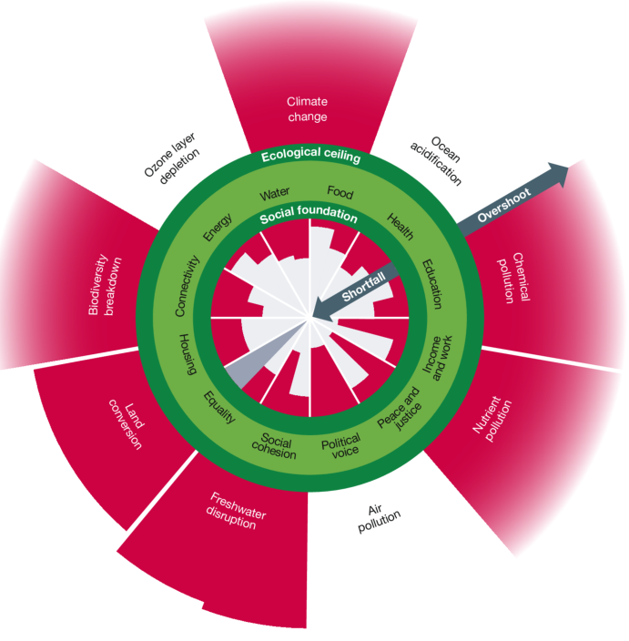

The peer-reviewed paper provides detailed explanation of the different indicators comprising both the ecological ceiling that defines overshoot and the social foundation that defines the floor and potential shortfalls in production.

### The Journal Article’s Contributions

The journal article “unrolls the donut” (Raworth is skilled with words) and provides specific indicators for measurement as well as peer-reviewed methods behind their calculation.

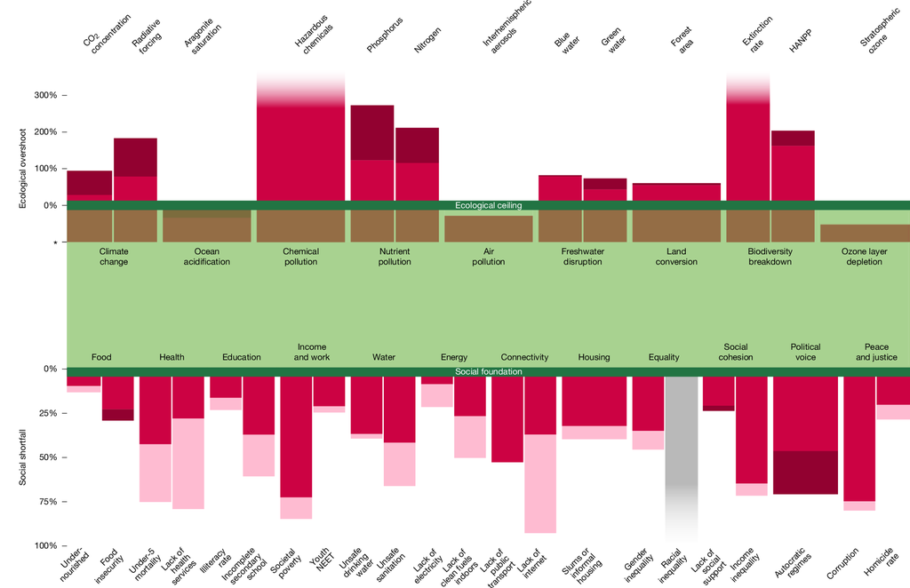

### Trends Over Time

The paper also shows general movement in these indicators over time. On the planetary boundary indicators, light red to dark red shading shows changes over the last two decades, with many indicators getting worse.

Simultaneously, on the social foundation, some indicators are declining. Food insecurity is actually getting worse, moving from red to dark red. However, many indicators are improving, moving upward from where they began.

Although much is concerning, especially regarding the ecological ceiling, the situation is nuanced because many things are simultaneously improving. Statistics from the previous class showed how things are getting better. This illustrates the importance of considering both Earth and economy. The ecological indicators represent negatives, but substantial improvements are occurring in education, health, housing, connectivity, and most social indicators. Political voice is not doing as well, but overall social progress represents a positive story.

### Ecological Ceiling Indicators

The ecological ceiling indicators define the planetary boundaries beyond which environmental systems face dangerous levels of stress. These include measures of climate change, ocean acidification, chemical pollution, nitrogen and phosphorus loading, freshwater use, land conversion, biodiversity loss, air pollution, and ozone layer depletion. Each indicator has specific quantitative thresholds based on scientific understanding of Earth system processes.

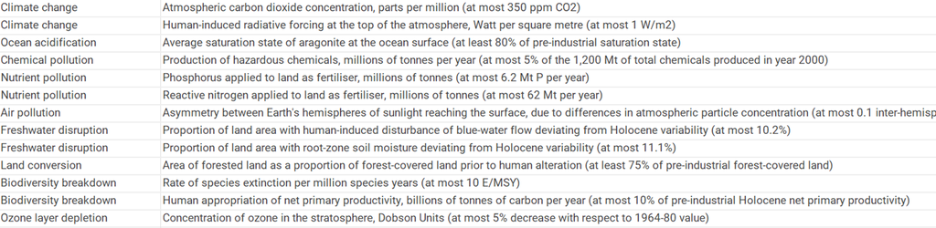

### Social Foundation Indicators

The social foundation indicators define the minimum standards below which human deprivation occurs. These include food security, health, education, income and work, water and sanitation, energy, networks (connectivity), housing, gender equality, social equity, political voice, and peace and justice. Each indicator uses specific measurable metrics to assess whether populations are meeting basic needs.

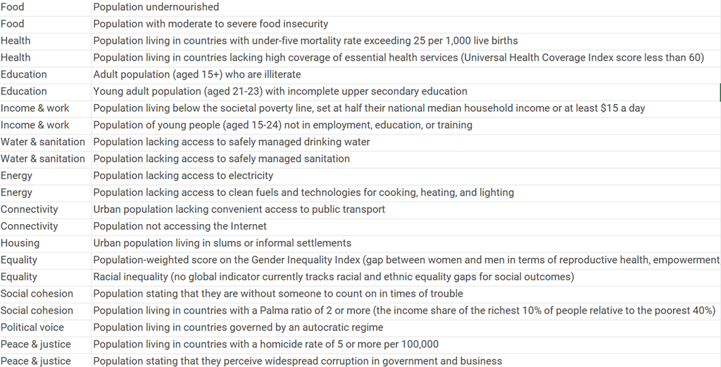

# Transcript

Alright, why don’t we get started? Hello, everybody, and welcome to Monday. It’s sad that we did not get to meet on Friday, but there was a lot of other things going on. There was extreme cold and ice. So today, I want to pick up where we left off.

We’re going to do a little bit more of the review of the syllabus. I got so excited last class about the lecture content that we were going to talk about that I did not really describe the syllabus, and that’s an important part so that you have clear expectations for this class. I also will be introducing in a moment Ryan McWay, our TA for this class. Let’s just do that now. Why don’t you give us a sentence or two or three about yourself.

I’m a PhD student. I’ve worked a lot with Justin over the last 4 years, and my focus is on environmental and development economics. I’ve been in your shoes, happy to help you any way I can.

Thank you. So Ryan will be mostly responsible for grading, and if you have any grading questions, like you disagree with the points, or you just had a question about why you got the grade you did, go ahead and email him. His name and email address is already on the website. If you email me about grades, I’ll probably just forward you along to him. But that’s just to keep me sane. It’ll be like a weekly cadence we hope to keep on Thursdays or something like that. We’ll come up with the pattern for when things will get graded.

So that’s Ryan. You can hang out if you want. I just wanted everybody to be able to attach a name to a face so that you’re not just an email link. Thank you.

Okay, did everybody have a good weekend? It’s going to get warmer, right? I’m so sick of this cold.

I just want to quickly touch on a few last things in the syllabus. If anybody needs one, I still have a few extra copies. Hopefully that’ll be the only piece of paper we hand out in this class. Regarding modality, this is technically an in-person class, even though things as of late have been quite challenging. You hopefully got my Canvas announcements about the Friday class going asynchronous, and here asynchronous just meant a relatively brief assignment. That was just because there’s so much going on in the rest of the world that I didn’t really want to have a whole ton of content on a busy day. But now we are going to pick up a little bit, and in-person attendance is required. We’ll talk about grading in a minute.

As some of you have already exercised, if you have any outstanding reasons you need to skip class, that’s totally understandable. I’m pretty generous on excused absences, so just reach out to me in advance. If possible, obviously if it’s an emergency, don’t worry about it beforehand. Just make up for it after the fact. But we will be keeping track of those things, so you don’t want to lose points for no good reason. This is hopefully going to be really interactive, much more so than if you took 1101 from me, where we had too large a class.

The specifics of grading are also in the syllabus, but I’ve reproduced it here with a few comments. Weekly questions: you’ve already had one. I think I incorrectly said it was due on Sunday. I meant to say it was due on Monday, and so if you haven’t submitted it, you still have time.

It was just asking you to look through the topics on the schedule. I want to get a quick reading, based on almost no context, about which ones are the most interesting to you. We may have to cut some of the content because there is a lot there, and I’d like to know your preferences. That’s a really quick one due this week, but there’ll be another one assigned on Friday and turned in on Monday. By the end of the day Monday, you have to have that turned in on Canvas. These will be really short. That’s 20% of your grade.

The problem sets are another 20% of your grade. These will be pretty straightforward. They’ll be basic to intermediate economics questions applied to environmental topics. You can expect something like solving the supply and demand system, and now doing it again with an externality. Obviously, we’ll talk through how to do that, but that’s what problem sets will be.

The midterm is 15%, and the final exam is also 15%, so only 30% of this course is on exams. Hopefully that’s appreciated. I don’t like having exam-heavy classes.

The two that require more explanation: first would be the final project. I’ll be assigning more information, but throughout the semester, we’re going to be building up towards making a country-specific Earth economy report. Each of you are going to be assigned a specific country. We’ll have a process for figuring out who gets which country, but you will be applying a lot of the techniques and skills we’re going to learn, such as modeling spatial ecosystem services, for that country. That’s 20% of your grade. It will also include interactive elements, like country debates. There are very contentious debates in international settings about different climate accords. Those may be the most famous, but there are also all sorts of negotiations about biodiversity regulations and commitments to protecting areas of critical habitat.

For class participation, in addition to attendance and in-class participation, where if you do the bare minimum you’ll probably get the 10%, I’m implementing something new called class points, or CP.

Class points are an incentive system. We’re economists, right? We often think about how incentives shape behavior. I wish I had money to give out because subsidizing good behavior is the right way to do it. Turns out that’s not ethical. I probably shouldn’t be trying to bribe people into learning economics. So instead, I’ve invented class points.

I’ve listed some of the things you might do to get them. They’ll often be awarded impromptu, like if you made a really good point in class. We will have multiple in-class activities. There may even be some where we illustrate game theory. Whenever I teach game theory, I always bring in chips or something like that, but nobody really wants chips. So what might you want? Class points.

The reason is because class points can be exchanged for various services in this class. You can spend 5 class points, and we will waive the late penalty for any assignment. Or 10 class points, and you’ll get 100% for free on the weekly questions. This is to incentivize you to care about class points. Also, ending the semester with the most class points will give you massive bragging rights. We’ll see how this plays out, but it’ll be like a running list of who’s winning the class.

Any questions about any of those things? Nobody wants to get any class points right off the bat? I won’t take away class points. That would be kind of cruel.

So that’s grading and expectations. One last thing I didn’t put on the slides is in the syllabus: the late work policy is 10% off per day after the deadline, but it hits a minimum at 50% value. This means even if you’re super late, you can still get half of the credits for any of the assignments. That gives you flexibility and a chance to recover if you do fall behind.

Another update: the website is now up to date. Let’s go live and look at the website.

Hopefully you’ll get comfortable here. That’s where our syllabus is, the textbook, everything. You can see it’s starting to populate, so bookmark this page. For instance, this is where you’d access the video. You can see here I’ve actually got it embedded in the page.

I’m trying to make this as open source and open science as possible, including the videos. I didn’t hear from anybody about being uncomfortable with these videos going live. Obviously, the camera will never be pointed on you, so I did post this one, but if at a later point it does make you uncomfortable, let me know. We’ll figure it out.

I want to emphasize that the presence of these recordings shouldn’t incentivize you to not come to class. That’s why I have attendance requirements. Every professor talks about the downside of providing notes or videos of lectures lessening the incentive to attend class. But this is important, and I really want everybody to be here.

Over here, this is all the content. We did the introduction. We’ll be working on this today. The content is not yet generated, but this is where you’d click to find the slides for today.

I highly recommend, and for some lectures I’m actually going to softly require, that you bring your laptops to class. We will actually be doing some geographic information systems on your computers. Contact me in advance if you think it’s not a possibility to bring a computer, but I’m seeing many people do have them. It’s also useful because you can follow along on the slides.

At least for the first class, in addition to the video, I’m also writing the textbook. This doesn’t mean you should skip class and just read the textbook. This might look familiar; it’s exactly what we talked about. I’m trying to use this teaching exercise as an opportunity to create content for an open access textbook eventually. This is lacking images still, but I’ll be putting those in.

Any questions on the website?

Alright, let’s go back to the slides.

I chose for the first day of class to talk about the general context. Why do we care about environment and natural resource economics? I specifically looked at it from the angle of how we should think about the Earth and the economy as interlinked. I wanted to do that before talking through the schedule because it’s always boring talking through schedule details without the framing.

One of the value-added elements of this course, compared to a traditional environment and natural resources (or ENR) course, is that I’m trying to put a global framing on top of it. When I took these courses, they felt like little slices that were unrelated. How do you optimally manage fisheries? How do you prevent pollution when it’s a non-point-source problem? Those are all important questions, and we will talk about those, but I’m going to try to create a broader framing that ties everything together.

On the website, the left-hand side is the content that goes into the final book I’m creating, but it’s the schedule on the right that says which parts you need to read. There’s probably going to be more here than you need, but if it’s not in the schedule itself, you don’t necessarily need to read it. The reason for this is because the schedule updates if, for instance, class was canceled.

Now I want to talk through the general framing. This is going to correspond exactly to the different sections within the website.

First, we’ve already done number one, the introduction. This is the global context, setting out the argument that environment and natural resources needs to be seen in a global setting.

The second lecture, today, is going to be talking about the donut, or macroeconomic boundaries. I introduced it very briefly on the board, but now we’re going to dive in and spend more time with it. It’s a very useful conceptual framework that combines environmental and economic indicators in a useful way.

Once we have the broad context in place, we’re going to review some of the specific economic tools. Here I can’t help but make a pun: the micro-filling. I’m thinking of a filled donut. There is a really strong contribution of economics, which is that it has a comprehensive and theoretically sound basis for why people do what they do.

I think it’s really cool, even though it can be abused in many cases. We’ll go much further than you would in an 1101, but probably not as far as you would in a 3000-level intermediate micro. We’re going to talk about it from the perspective of consumer preferences, utility curves, and indifference curves, and use these things to build up the fundamental tool underneath the rest of ENR.

From there, we’ll reintroduce supply and demand very quickly, but that’s going to be central in a lot of things like externalities. These two things together are enough to define cost-benefit analysis.

When you ask a lot of people what the point of environment and natural resources is in our policy space, they might point to improved cost-benefit analysis. That’s been a critical part of the environmental protection journey that various countries have undergone. We don’t just build a plant or do some potentially polluting thing without considering all the costs and the benefits. This is particularly important in environmental domains because environmental costs are often ignored by the person who really wants to build the factory.

We’ll build that out and apply it to the concept of optimal pollution. Because we have econ-minded people here in this class, this is not something I probably have to sell. But whenever I teach this to ecologists, they often really dislike the idea of optimal pollution because they might say pollution should have none of it.

I’m going to argue that that’s not true, and they really dislike it, but I always win in the end. There are marginal benefits to getting rid of pollution, that’s really clear, but there are also marginal costs of abating. We’ll build that framework out to show that the result is some level of pollution is optimal. However, it’s almost always way less than we have now.

That’s part two: refreshing and repurposing our economic tools towards the environment.

Once we have those tools, we’re going to do the first of the two bread-and-butter parts of a typical environment econ course: using the tools to understand market failures. In your intro class, you probably talked about market failures and these three in particular: externalities, public goods, and commons dilemmas. Those are three cases where perfect competition falls apart and is not optimal. Either we have to put up with the badness, or we could hopefully solve the market failures.

Typically, a course like this would spend most of its time talking about, using climate change as an example, how emissions generate externalities. The coal-fired power plant owner is caring about the profitability of their electricity but maybe not the impact they have on the rest of the world through climate damages.

Climate change has externalities, yes, but it’s also a public good. If you wanted to protect our climate and reduce some emissions, you will get the benefits of that. But the problem is, so does everybody else. We’re just 1 out of 8 billion people. Your personal benefits from reducing your own emissions are pretty small. So it’s also a hardcore public goods problem.

Same thing with the climate being a commons. The atmosphere’s capacity to absorb carbon is a finite commons good, but there’s no way to prevent people from using it. For all these three things, we’re going to use climate change throughout as an example of the ultimate market failure because it fails on all three of those points. There are many other market failures that you might see in a course like this, like stinky hog manure or something that has spillover effects, but we’re going to emphasize climate change.

With that environment framing in place, we’re now going to add a little bit that is newer to the discussion. We’re going to zoom back out and think about it with more detailed indicators of macroeconomic sustainability. This is where the new framing comes in. We’re going to think about how all parts of the economy are impacted and how they all fit together in a complex equilibrium. We’re going to talk about general equilibrium, but a more general version that considers the Earth.

We’ll talk about GDP as a flawed indicator and discuss potential replacements for it. Although, actually, I argue it’s a pretty good indicator for what it’s good for.

That will set us up to talk about the Kuznets Curve, which is a relationship between how a country’s environmental damages go up as their income rises, but then eventually, so the theory posits, starts to fall. We’ll talk about those interactions and the evidence for that.

Then we’ll talk about inclusive wealth, which for me is a better indicator than GDP. I like GDP, but it misses so much. There are many possible replacements. We’ll talk about this one in particular as a strong contender for what I would argue is a really good replacement. That’s because it lets us talk meaningfully about sustainable development over time.

Then, the big elephant in the room: climate change. We’re going to address it head on. We’ll have talked about it a lot, but we’re now going to use specific tools to measure, for instance, the social cost of carbon, the SCC. This is a very frequently used measurement of damages from climate change, and it’s behind lots of policies like carbon pricing or carbon taxing. We’re actually going to get our hands dirty with some integrated assessment models. These are the underlying tools used to establish the actual social cost of carbon. They calculate who gets damaged and by how much.

Part six of the course is the other bread-and-butter issue in a traditional course: natural resource management. We’ll look at a variety of different types of natural resources. Non-renewables: are we going to run out of them? As well as some renewable resources like fisheries and forestry. One thing I’m going to argue is that land itself is an important resource. In fact, I’ll argue it might be one of the most important resources because land itself is a limited resource, at least so far, because we only have Earth. Whereas other resources are a little bit less likely to hit hard limits.

Then we’re going to transition into my favorite part of the course: natural capital and new methods. Most ENR courses would have maybe a chapter on natural capital and ecosystem services. We’re going to have a bunch. We’re going to dive deep on this. Ecosystem services are an economic valuation of how much people benefit from nature, putting a dollar value on nature. We’ll talk about the pros and cons of that, but also, we’ll do explicit methods such as using a model called InVEST, which is the Integrated Valuation of Ecosystem Services and Trade-offs. You’re even going to learn some basic GIS skills. It will all be open source software, so you don’t have to worry about not having access.

Moving to the end of the semester, we’ll say: what does the future look like? With this framing at the global scale, where does it seem like we’re going? And the tightly related question: where do we want to go? Not just what’s likely, but what would be different if we figured out how to work collectively as an international collective to set good policies in place.

We’ll then talk about the specifics of those policies, both market-based and non-market-based, as well as existing environmental laws.

I want to end the course with a synthesis that comes back together and talks about routes forward in Earth economy modeling. That will highlight a few things, like how we are getting ever better data and improved spatial representation in these models, and that’s unlocking fundamental advances in understanding how the environment affects the economy and vice versa. We’ll also talk about specific use cases. How do governments, NGOs, development banks, and all sorts of other organizations currently engage with this?

For better or worse, I’m right at the center of this, and that might be a bad thing because I’m constantly being taken away from teaching responsibilities. I almost decided to buy out myself, where I can use money I fundraised to not have to teach, because there is so much demand surging for this. But I decided I didn’t want to do that because being able to talk about these concepts for all different audiences is a really important thing. That’s actually behind my motivation for creating the book.

This is awkward to do, but I want to give a little bit of motivation by discussing the demand for Earth economy modeling and how it’s increasing. It’s embarrassing because I’m a good Midwesterner. That means I don’t like bragging about myself and I like being humble. I wouldn’t normally do this, but it’s just popping off. Here I was logging on to what I thought was going to be a call of 15 people from the OECD, and it turned out to be about 350 people. So I was totally surprised by things like this.

Here’s me presenting at the Central Bank of Chile. Big bouncer guy in front of one of the largest doors. We actually got to tour the vault. They flew me out business class. I’d never been business class before. I had a door on my seat. It was international business class. I felt guilty, but they paid for it.

Here’s me speaking at the European Commission, making it to their main place and working with all these other organizations. Another interesting one is the Norwegian Sovereign Wealth Fund, or the Norges Bank Investment Management. This is the world’s biggest investment fund. It’s about $4 trillion. They had a lot of oil, and they put it into the sovereign wealth fund.

Now they’re asking really important questions, like how can we be sustainable with this? But also, what are the risks to our wealth and prosperity from degraded nature? They’re both thinking of the good of everybody and the good of their investments. I had to wear a suit to that event. This is my wedding suit. I hadn’t worn it in a really long time.

Here I went to the French central bank, and we went to this private golden hall. This room has the record for the most gold plating on the ceiling and walls, so it was quite impressive.

The final one I’ll end with: we’ve launched a brand new research center here at the university. This is in this building, just up on the third floor. If you come to my office hours, this is NatCap TEEMs. NatCap is the natural capital that we’ll talk so much about, but TEEMs is the Earth Economy Modelers. This is personal for me. I want this research center to grow, I want this research direction to succeed, and that’s why I am perhaps too passionate about this.

I also set that all up to say I’m extraordinarily busy, so I apologize if I’m slow to answer emails. I have a lot of weekend traveling that I do to meet with different organizations and banks to talk about this. But it’s been fun. It’s been a crazy time.

Any questions about the course overview or where we’re going?

Alright, let’s start diving in. The one I want to dive into is what the reading was on: the details of the planetary donut.

This is something that has been out since 2017. There were some prior books, but it really hit the mainstream in 2017 from an author named Kate Raworth. She has since become quite famous for this. Very recently, it’s finally now peer-reviewed in arguably the best of the scientific journals. That’s Nature. I’d argue Science is better if I really wanted to get into a fight with my colleagues, but Nature is considered by many to be the best. So it’s really hitting the mainstream.

One of the things in this paper is what we didn’t get into last class: a detailed explanation of what are the different indicators of that ecological ceiling that define the overshoot, as well as the indicators of the social foundation that define the floor and what would be a shortfall in production.

This journal article unrolls the donut (she’s good with words) and starts to provide specific indicators for how these are measured, as well as peer-reviewed methods behind the calculation of these indicators.

We’ll dive into the specific indicators in a minute, but I wanted to highlight one more thing. She also shows the general movement in these indicators over time. What you can see here on the planetary boundary ones is the light red to the dark red showing the change over the last two decades. You can see a lot of them are getting worse.

Simultaneously, on the social foundation, we see that there are some that are going down. Food insecurity is actually getting worse. It’s going from red to dark red. But many of them are increasing. That’s illustrated by, at the beginning of the time period, it was down here, and we’ve moved up to here.

Although there is lots to worry about, especially on the ecological ceiling side of things, it is a nuanced question because we are also simultaneously improving a whole bunch of things. I threw a bunch of statistics at you last class about how things are getting better, but this is where it really illustrates to me the importance of considering both the Earth and the economy. This is a negative up here. But we’re doing a lot better. Education is improving, health is improving, housing, connectivity, all these indicators are by and large getting better. Political voice is not doing so well. But this is a positive.

I want to engage with this. I just don’t want to lecture the whole time. We’ve got a smaller class, let’s take advantage of it. We’re going to have a class discussion here for about 5 minutes, and we’re going to do what I call a quad-split discussion. Has anybody done one of these before or something similar?

It’s hard to get a whole large group of people talking, but what I’m going to ask you to do is identify groups of approximately 4 people who are nearby you. I’m probably going to help by just chunking you into four groups. You’re going to discuss the prompt on the next slide. One of you will then report back to the group. That way, I’m not putting you on the spot. You get to decide who it is, and you have some time to plan. This is where you get your class participation points.

As a group, you’ll choose who that reporter is going to be. Just as a failsafe, if you can’t decide, it will default to whoever is alphabetically right after the letter A. I will be changing around this letter when we have different quad splits. Whoever’s earliest in the alphabet here.

The idea is to have a small group discussion for about 5 minutes, and then we’ll have a report back.

Another side note: in this era of AI, this is also important to be good at discussion. If I were to assign this as an out-of-class writing exercise, this would be trivially easy for you to use AI to answer. That’s a problem. So we’re going to rely a little less on written exercises and instead have in-class discussions, because that’s really a way to showcase that you, in fact, are learning, rather than just able to input prompts into ChatGPT.

First, I’m going to split you into our different quad groups. You four, slide together. You four will be a group of four. The first two rows here is the third group, and the back two rows over there is the fourth one.

On subsequent lectures, I might actually ask people to sit closer together, like in the first two rows, so that we don’t have this awkward moving around all the time. But I’ll take feedback on how to make this easier.

So those are our groups.

What I want is, on your computer or phone, navigate to those two indicator tables. An easy way would be to look at the PowerPoint slides posted on Canvas, but you could even go to Donut Economics, the Data Explorer, to take a look at them. I also have links to where they were reported in the peer-reviewed literature.

I want you to rank, as a group, two different things. First, the top three scariest of the ecological indicators. This could be subjective, so you’ll have some discussion and maybe come up with some points about why one is particularly concerning to your group.

Second, rank as a group the three most important social indicators. Here, importance is even more vague. You can interpret it however you want, but one potential way of addressing it is: how much would you care if we could successfully address that social indicator? Which one drives you? For me, social justice is one of the ones that really drives me on a day-to-day basis, especially with events going on.

Let’s start the discussion. We’re going to talk as groups for 5 minutes, and then we’ll report back at 25 after the hour. Dive in. Feel free to move closer. Also, introduce yourself again to your small group so you can all talk.

The last thing I want to mention, and then we’ll call it good for here: for Friday, or maybe on Wednesday, for this week’s weekly writing, I’m going to have you choose one of these countries. You’re going to list your top 3 countries that you would be most interested in having as your country for our country reports. I’ll share more details, but if you want to get thinking, I chose these ones because of data availability, and they’re also quite small so that even if you don’t have a super-fast computer, you’ll be able to calculate ecosystem services on them in a smaller amount of time.

So that’s just a shout out to where we’re going. Thank you, everybody. Thanks for bearing through the cold of yet another cold day. If you have any questions, feel free to come on up. Thank you.

# Appendix

## Learning objectives

After this chapter, you should be able to:

- Define a **coupled human–natural system** and give examples relevant to climate, land, water, and biodiversity.
- Use **stock–flow** thinking to explain why some environmental damages are slow to appear and hard to reverse.
- Explain the **Doughnut Economics** framing (social foundation + ecological ceiling) as a way to define goals for sustainability policy.
- Describe why “**the economy is embedded in the biosphere**” is not a metaphor, but a modeling constraint.
- Preview how this framing motivates **inclusive wealth** and **Earth–economy models** later in the book.

## Core ideas

### 1) Environmental problems are coupled systems problems

Many sustainability challenges are not “one market failure” in one sector. They are systems where:

- economic decisions change the state of ecosystems,
- ecosystem changes feed back into productivity, health, risk, and conflict,
- and policies ripple through supply chains, land-use decisions, and institutions.

A useful mental model is:

> **Drivers → Pressures → State → Impacts → Responses**  
> (and each arrow loops back through behavior and policy).

You don’t need advanced math to think in systems terms, but you do need discipline about *what depends on what*.

### 2) Stock–flow thinking (the quiet engine behind sustainability)

A **flow** is a rate (tons CO₂ per year, hectares deforested per year).  
A **stock** is an accumulated state (atmospheric CO₂ concentration, forest carbon, groundwater level, species richness).

Key idea:

> **Flows change stocks; stocks shape future flows and damages.**

This is why many sustainability problems feel “fine until they suddenly aren’t.” Stocks can drift for years, then cross thresholds.

Examples:

- **Climate:** emissions (flow) increase atmospheric concentration (stock), which changes temperature and damages.
- **Groundwater:** pumping (flow) lowers aquifer levels (stock), which increases pumping costs and can cause saltwater intrusion.
- **Biodiversity:** habitat conversion (flow) reduces populations (stock), lowering ecosystem resilience and services.

This is the backbone of environmental and resource economics: many policy problems are really about managing **stocks over time**.

### 3) The Doughnut: defining the goal as “safe and just”

Kate Raworth’s Doughnut framing is a high-level way to define what “success” should mean:

- **Social foundation:** minimum standards for human well-being (health, education, food, energy access, equity, voice).
- **Ecological ceiling:** biophysical limits that should not be breached (climate stability, biodiversity, nutrient cycles, freshwater, land conversion).

The “doughnut” is the space between them:

> a world that meets everyone’s needs **within** Earth’s life-supporting systems.

In this book, we’ll treat that space as the normative target and then ask: - What policies move us toward it? - What metrics tell us whether we’re moving? - What models can evaluate tradeoffs and unintended consequences?

**Important licensing note:** Raworth’s *book* is not an open-license textbook. We’ll use the *ideas* in our own words. Where we point you to Doughnut materials (diagrams, chapter excerpt), treat them as **reading/teaching tools**, not content to paste into your CC BY-NC-SA book unless licensing explicitly allows it.

### 4) Why economists are useful here (even when markets fail)

Systems framing can make problems look overwhelming. Economics helps you answer practical questions:

- Which behaviors are driving pressures?
- What incentives and constraints shape those behaviors?
- Which institutions and power structures lock them in?
- Which policy levers change the payoff landscape?

Economics is not “pro-market” by default. It is **pro-clarity** about tradeoffs, distribution, and implementation.

## A worked example: land-use change as a coupled system

Consider a simplified land-use story:

1. **Demand increases** for beef/soy/palm oil (economic driver).
2. Producers respond by expanding agriculture (pressure).
3. Expansion causes **deforestation** (state change).
4. Forest loss reduces carbon storage and biodiversity (impacts).
5. Carbon emissions worsen climate risk; biodiversity loss reduces resilience (feedback impacts).
6. Policy responses (protected areas, supply-chain rules, carbon pricing) change incentives (responses).
7. Producers shift locations or practices (leakage, intensification) (system feedback).

Takeaways: - “Ban deforestation” is not a full plan unless you model leakage and supply-chain responses. - “Price carbon” is not a full plan unless you model land competition and food prices. - The Doughnut framing clarifies the target, but policy design requires coupled-systems reasoning.

## Connections to Earth–economy modeling

Earth–economy modeling is the attempt to make coupled-systems reasoning *operational*:

- Economic modules explain production, consumption, trade, prices, and income distribution.
- Biophysical modules explain land cover, carbon, water, habitat, ecosystem services, and risk.
- Linkages ensure feedbacks are explicit: land affects yields, yields affect prices, prices affect land.

This book will build toward three modeling instincts:

1. **Write down the stocks.** (carbon, land, biodiversity, wealth assets)
2. **Make feedbacks explicit.** (prices ↔︎ land, policy ↔︎ behavior, ecosystems ↔︎ productivity)
3. **Track the metrics that match the Doughnut.** (needs met + ecological limits respected)

Those instincts will show up again when we discuss: - GDP vs inclusive wealth, - natural capital and ecosystem services, - and why partial-equilibrium intuition often fails for sustainability questions.

## Open resources you can incorporate into this chapter (remix-friendly)

- **Natural Resources Sustainability: An Introductory Synthesis (CC BY-NC-SA)**  
  Use for: systems framing, sustainability, natural capital.  
  https://uen.pressbooks.pub/naturalresourcessustainability/
- **InTeGrate teaching materials (many are CC BY-NC-SA; check page-level license/provenance)**  
  Use for: system diagrams, activities, case studies (climate, food-water-energy, land use).  
  https://serc.carleton.edu/integrate/teaching_materials/index.html

(We’ll keep the “license hygiene” simple: only remix materials that clearly allow adaptation under CC BY-NC-SA.)

## Doughnut Economics resources (recommended reading/tools)

Use these as readings and visuals for students; do not paste them into your book unless you confirm compatibility with your chosen license.

- **What is the Doughnut? (DEAL tool; licensed CC BY-SA 4.0)**  
  https://doughnuteconomics.org/tools/what-is-the-doughnut
- **Chapter One of Doughnut Economics (DEAL; made available with permission; tool licensed CC BY-SA 4.0)**  
  https://doughnuteconomics.org/tools/chapter-one-of-doughnut-economics

If you want a doughnut figure *inside* your CC BY-NC-SA book, the simplest route is: - draw your own original schematic (social foundation + ecological ceiling) in your own style, - cite Raworth/DEAL conceptually, - and keep it clearly your own artwork.

## Exercises

1. **Stocks vs flows (short answers).**  
   For each pair, label which is the stock and which is the flow:
   - 1. atmospheric CO₂ concentration vs annual CO₂ emissions
   - 2. groundwater level vs pumping rate
   - 3. forest carbon vs hectares deforested per year
2. **Draw a feedback loop (hand sketch).**  
   Choose one system:
   - land-use change, or
   - fisheries, or
   - urban air pollution.  
     Draw at least one feedback loop that includes:
   - a human decision,
   - an ecosystem state variable,
   - and an economic consequence.
3. **The Doughnut as a policy target (one paragraph).**  
   Choose a country or region you know. Give one example of:
   - falling short of the social foundation, and
   - overshooting the ecological ceiling,  
     and explain why policies might create tradeoffs between the two.
4. **Earth–economy modeling preview (reflection).**  
   Describe one reason why a partial-equilibrium policy analysis could fail for your chosen system (e.g., leakage, rebound, price effects, migration, substitution).